# Minería de Datos

Clase 9: Tablas, Gráficos y Distribuciones de Frecuencia

Departamento de Estadística, Sede Bogotá

## Contenido de la clase

#### ¿Qué gráfico usar?

- Tipo de dato vs tipo de gráfico
- Categóricas y numéricas
- Relaciones y series de tiempo
- Regla de oro

#### Herramientas de visualización

- ggplot2: gramática visual
- plotly: interactividad
- highcharter: gráficos elegantes
- Tablas: kable, gt y pandas

#### Distribuciones de frecuencia

- Frecuencias absolutas y relativas
- Histograma y densidad
- Boxplot y violin
- Distribuciones comunes

Parte 1

## ¿Qué gráfico usar?

El tipo de dato y la pregunta analítica determinan el gráfico. Elegir mal distorsiona el mensaje, aunque los datos sean correctos.

## La pregunta antes del gráfico

Antes de abrir cualquier librería, responde: **¿qué quiero comunicar?**

Comparar

¿Cuánto tiene cada categoría?

Distribuir

¿Cómo se reparte una variable?

Tendencia

¿Cómo cambia algo en el tiempo?

Relacionar

¿Qué asociación hay entre variables?

## Mapa de decisión: tipo de dato y gráfico

| Situación | Gráfico recomendado | Alternativas |
| --- | --- | --- |
| 1 variable categórica | Barras verticales u horizontales | Lollipop, waffle |
| 1 variable numérica | Histograma | Densidad, boxplot |
| 2 variables numéricas | Dispersión (scatter) | Hexbin, smooth |
| Categórica + numérica | Boxplot por grupo | Violin, jitter |
| Variable en el tiempo | Líneas | Área, escalón |
| Partes de un todo | Barras apiladas (100%) | Treemap, waffle |
| Muchas variables numéricas | Mapa de calor de correlaciones | Pairs plot |

## Una variable categórica

#### Barras verticales

Ideal cuando hay pocas categorías y los nombres son cortos.

- Fáciles de comparar alturas
- Ordenar de mayor a menor ayuda

#### Barras horizontales

Mejor cuando los nombres son largos o hay muchas categorías.

- Más legibles con etiquetas extensas
- Funcionan bien con rankings

**Evitar:** los gráficos de torta (pie charts) cuando hay más de 3-4 categorías. Las diferencias angulares son difíciles de percibir.

## Una variable numérica

#### Histograma

Agrupa valores en intervalos. Revela forma, concentración y outliers.

Primer paso recomendado

#### Densidad (KDE)

Suaviza el histograma. Bueno para comparar grupos superpuestos.

Complementa el histograma

#### Boxplot

Resume mediana, IQR y outliers. Compacto y robusto.

Ideal para comparar grupos

Los tres se complementan: el histograma muestra forma, la densidad suaviza, el boxplot resume de forma robusta.

## Dos variables numéricas

#### Dispersión (scatter plot)

Un punto por observación. Muestra la relación entre dos variables.

- Agrega `color` para una tercera variable
- Agrega `size` para una cuarta
- Usa `geom_smooth()` para la tendencia

#### Hexbin o 2D-densidad

Útil cuando hay demasiados puntos y el scatter se satura.

- El color representa la densidad local
- Mejor para n > 5.000 observaciones

## Categórica + numérica

#### Boxplot por grupo

Compara mediana, dispersión y outliers entre categorías. Robusto y clásico.

#### Violin plot

Muestra la distribución completa. Más informativo que el boxplot, pero más complejo de leer.

#### Jitter + boxplot

Superpone puntos individuales sobre el boxplot. Honesto con el dato real.

Combinar boxplot + jitter es una de las mejores prácticas para datasets medianos (n < 500).

## Serie temporal y partes de un todo

#### Serie temporal: líneas

Conecta mediciones ordenadas en el tiempo.

- No usar barras para series continuas largas
- Múltiples líneas para comparar grupos
- Área rellena para enfatizar magnitud

#### Partes de un todo

Muestra cómo se divide el 100% entre categorías.

- Barras apiladas al 100%: mejor que la torta
- Treemap: cuando hay jerarquía
- Waffle: para porcentajes simples y redondos

## Regla de oro del gráfico

Un buen gráfico responde **exactamente una pregunta**, de forma que quien lo ve no necesite preguntar qué significa.

1. Define la pregunta antes de abrir R o Python.
2. Elige el tipo de gráfico según el dato, no según la estética.
3. Etiqueta ejes, incluye unidades, pon título.
4. Usa color con función, no como decoración.
5. Evita el 3D, las tortas con muchas categorías y los ejes truncados sin aviso.

Parte 2

## ggplot2: gramática de gráficos

ggplot2 construye gráficos por capas. Cada elemento tiene un lugar preciso y se puede modificar de forma independiente.

## La gramática de ggplot2

Datos  
`data =`

→

Mapeos  
`aes(x, y, color)`

→

Geometría  
`geom_*()`

→

Escalas y tema  
`scale_*(), theme()`

#### Historia de ggplot2

1. Creado por Hadley Wickham (2005–2007)
2. Inspirado en el libro “The Grammar of Graphics” (Leland Wilkinson)
3. Publicación oficial en R alrededor de 2010
4. Se convierte en estándar para visualización en R
5. Parte del ecosistema tidyverse
- Código
- Gráfico

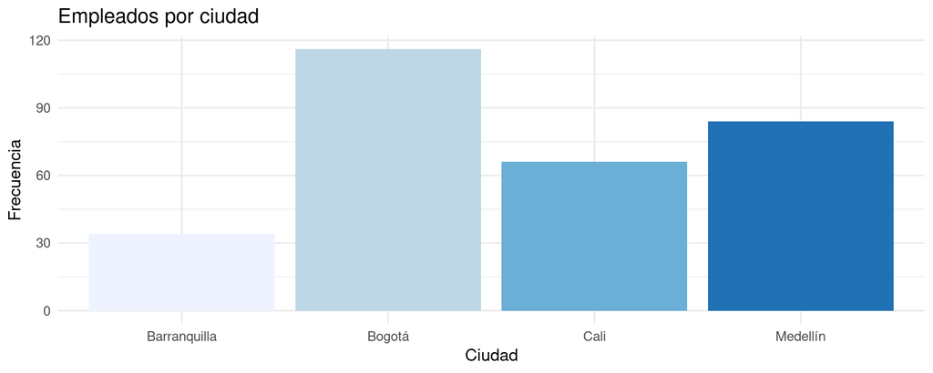

```r
empleados %>%
ggplot(aes(x = ciudad, fill = ciudad)) +
geom_bar(show.legend = FALSE) +
scale_fill_brewer(palette = "Blues") +
  labs(title = "Empleados por ciudad", x = "Ciudad", y = "Frecuencia") +
  theme_minimal()
```

## Datos de ejemplo: empleados colombianos

```r
library(tidyverse)
set.seed(2025)

n <- 300
empleados <- tibble(
  ciudad    = sample(c("Bogotá","Medellín","Cali","Barranquilla"), n,
                     replace = TRUE, prob = c(.4,.3,.2,.1)),
  sexo      = sample(c("Mujer","Hombre"), n, replace = TRUE),
  edad      = round(rnorm(n, mean = 35, sd = 9)),
  educacion = sample(c("Bachiller","Técnico","Universitario","Posgrado"), n,
                     replace = TRUE, prob = c(.2,.25,.35,.2)),
  salario   = round(rnorm(n, mean = 3200000, sd = 900000))
)
```

Nota Todos los ejemplos de esta clase usan este dataset. Ejecuta el bloque anterior antes de correr cualquier gráfico.

## Barras con ggplot2

- Código
- Gráfico

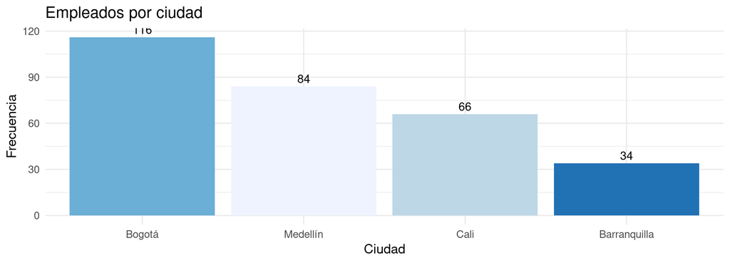

```r
empleados |>
  count(ciudad) |>
  ggplot(aes(x = reorder(ciudad, -n), y = n, fill = ciudad)) +
  geom_col(show.legend = FALSE) +
  geom_text(aes(label = n), vjust = -0.4, size = 4) +
  scale_fill_brewer(palette = "Blues", direction = -1) +
  labs(title = "Empleados por ciudad", x = "Ciudad", y = "Frecuencia") +
  theme_minimal(base_size = 14)
```

`reorder(ciudad, -n)` ordena de mayor a menor. `geom_text()` agrega etiquetas de valor sobre las barras.

## Histograma con ggplot2

- Código
- Gráfico

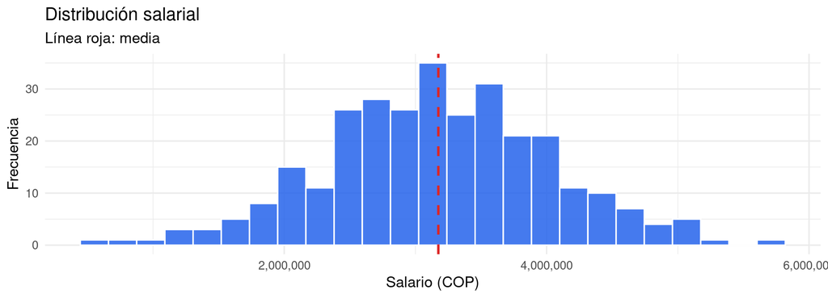

```r
ggplot(empleados, aes(x = salario)) +
  geom_histogram(bins = 25, fill = "#2563eb", color = "white", alpha = 0.85) +
  geom_vline(aes(xintercept = mean(salario)),
             color = "#dc2626", linetype = "dashed", linewidth = 1) +
  labs(title = "Distribución salarial", subtitle = "Línea roja: media",
       x = "Salario (COP)", y = "Frecuencia") +
  scale_x_continuous(labels = scales::comma) +
  theme_minimal(base_size = 14)
```

`geom_vline()` agrega la línea de la media. `scales::comma` formatea los números con separador de miles.

## Dispersión con ggplot2

- Código
- Gráfico

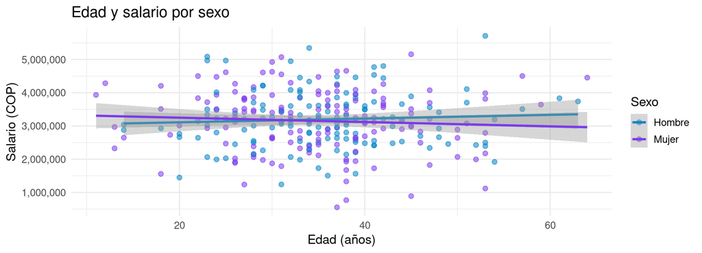

```r
ggplot(empleados, aes(x = edad, y = salario, color = sexo)) +
  geom_point(alpha = 0.55, size = 2.5) +
  geom_smooth(method = "lm", se = TRUE, linewidth = 1.1) +
  scale_color_manual(values = c("Mujer" = "#7c3aed", "Hombre" = "#0284c7")) +
  scale_y_continuous(labels = scales::comma) +
  labs(title = "Edad y salario por sexo",
       x = "Edad (años)", y = "Salario (COP)", color = "Sexo") +
  theme_minimal(base_size = 14)
```

`geom_smooth(method = “lm”)` agrega una recta de regresión por grupo, con intervalo de confianza.

## Boxplot con ggplot2

- Código
- Gráfico

[figure not shown]

```r
ggplot(empleados, aes(x = educacion, y = salario, fill = educacion)) +
  geom_boxplot(show.legend = FALSE, outlier.alpha = 0.4) +
  geom_jitter(width = 0.15, alpha = 0.25, size = 1.5, show.legend = FALSE) +
  scale_fill_brewer(palette = "Set2") +
  scale_y_continuous(labels = scales::comma) +
  labs(title = "Salario por nivel educativo",
       x = "Nivel educativo", y = "Salario (COP)") +
  theme_minimal(base_size = 13)
```

`geom_jitter()` muestra los puntos individuales encima del boxplot, evitando la superposición exacta.

## Composición con patchwork

- Código
- Gráfico

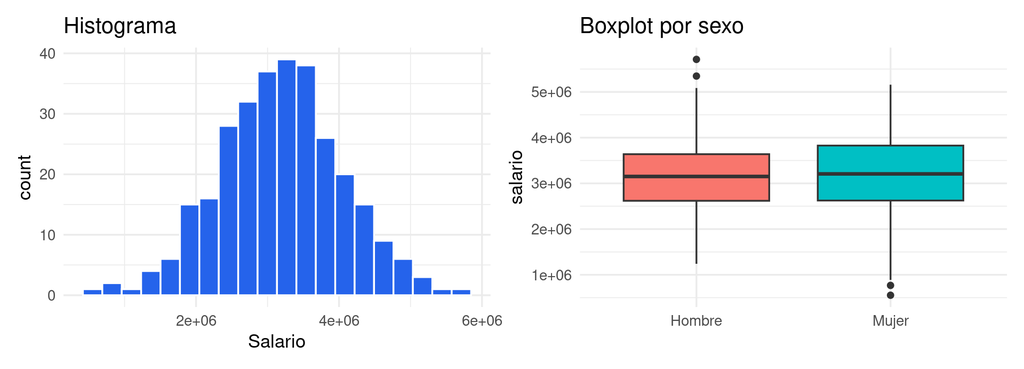

```r
library(patchwork)

p1 <- ggplot(empleados, aes(x = salario)) +
  geom_histogram(bins = 20, fill = "#2563eb", color = "white") +
  labs(title = "Histograma", x = "Salario") + theme_minimal()

p2 <- ggplot(empleados, aes(x = sexo, y = salario, fill = sexo)) +
  geom_boxplot(show.legend = FALSE) +
  labs(title = "Boxplot por sexo", x = "") + theme_minimal()

p1 + p2   # lado a lado
p1 / p2   # apilados
```

`patchwork` permite combinar objetos ggplot con operadores `+` (lado a lado) y `/` (apilados).

Parte 3

## plotly: interactividad en R

plotly convierte gráficos estáticos en interactivos: hover, zoom, filtros y tooltips, sin escribir JavaScript.

## ggplotly(): de ggplot2 a interactivo

- Código
- Gráfico

```r
library(plotly)

p <- ggplot(empleados, aes(x = edad, y = salario,
                            color = ciudad,
                            text = paste("Ciudad:", ciudad,
                                         "<br>Edad:", edad,
                                         "<br>Salario:", scales::comma(salario)))) +
  geom_point(alpha = 0.6) +
  theme_minimal()

ggplotly(p, tooltip = "text")
```

[interactive chart not shown]

`ggplotly()` convierte cualquier objeto ggplot en interactivo. El argumento `tooltip` controla el contenido del hover.

## plot_ly(): nativo de plotly

- Código
- Gráfico

```r
plot_ly(
  data = empleados,
  x = ~ciudad,
  y = ~salario,
  color = ~sexo,
  type = "box"
) |>
  layout(
    title = "Salario por ciudad y sexo",
    yaxis = list(title = "Salario (COP)")
  )
```

[interactive chart not shown]

La interfaz nativa de plotly usa `~variable` para el mapeo de datos y `|> layout()` para personalización.

## Cuándo usar plotly

#### Sí conviene

- Dashboards y reportes web interactivos
- Exploración con muchas observaciones
- Cuando el usuario necesita filtrar o hacer zoom
- Tooltips con información detallada por punto

#### No siempre conviene

- Diapositivas estáticas o informes impresos
- Cuando la claridad del mensaje es prioritaria
- Archivos muy pesados para distribuir

Parte 4

## highcharter: gráficos de alta calidad en R

highcharter es un wrapper de Highcharts para R. Produce gráficos interactivos elegantes, con tooltips, animaciones y un API expresivo.

## ¿Qué es highcharter?

**highcharter** lleva la librería JavaScript Highcharts a R. Permite crear gráficos interactivos de alta calidad sin escribir JavaScript.

Estética cuidada

Temas elegantes por defecto, sin ajustes manuales.

Interactividad

Hover, zoom, tooltips y drill-down nativos.

API amigable

`hchart()` sigue una lógica similar a ggplot2.

Documentación completa: **jkunst.com/highcharter** `install.packages(“highcharter”)`

## hchart(): barras

- Código
- Gráfico

```r
library(highcharter)

empleados |>
  count(ciudad) |>
  hchart("column", hcaes(x = ciudad, y = n), name = "Empleados") |>
  hc_title(text = "Empleados por ciudad") |>
  hc_xAxis(title = list(text = "Ciudad")) |>
  hc_yAxis(title = list(text = "Frecuencia")) |>
  hc_colors("#2563eb") |>
  hc_tooltip(pointFormat = "<b>{point.y}</b> empleados")
```

[interactive chart not shown]

`hchart(datos, tipo, hcaes(x, y))` es la función principal. El tipo puede ser `“column”`, `“bar”`, `“scatter”`, `“line”`, `“area”`, entre otros.

## hchart(): dispersión

- Código
- Gráfico

```r
hchart(empleados, "scatter",
       hcaes(x = edad, y = salario, group = sexo)) |>
  hc_title(text = "Edad vs Salario por sexo") |>
  hc_xAxis(title = list(text = "Edad (años)")) |>
  hc_yAxis(title = list(text = "Salario (COP)"),
           labels = list(format = "{value:,.0f}")) |>
  hc_tooltip(pointFormat = "Edad: {point.x}<br>Salario: {point.y:,.0f}") |>
  hc_plotOptions(scatter = list(marker = list(radius = 4, opacity = 0.6)))
```

[interactive chart not shown]

El argumento `group` en `hcaes()` crea una serie por cada valor del grupo, con colores automáticos.

## hchart(): serie temporal (líneas)

- Código
- Gráfico

```r
ventas_mes <- tibble(
  mes    = seq(as.Date("2024-01-01"), by = "month", length.out = 12),
  ventas = round(rnorm(12, mean = 85000, sd = 12000))
)

hchart(ventas_mes, "line", hcaes(x = mes, y = ventas), name = "Ventas") |>
  hc_title(text = "Ventas mensuales 2024") |>
  hc_xAxis(type = "datetime", title = list(text = "Mes")) |>
  hc_yAxis(title = list(text = "Ventas (USD)")) |>
  hc_plotOptions(line = list(marker = list(enabled = TRUE)))
```

[interactive chart not shown]

Para fechas, usa `hc_xAxis(type = “datetime”)`. highcharter convierte automáticamente los objetos `Date` de R.

## highstock: navegador temporal interactivo

- Código
- Gráfico

```r
library(highcharter)
library(tibble)

set.seed(7)
precios <- tibble(
  fecha  = seq(as.Date("2022-01-01"), by = "week", length.out = 104),
  precio = cumsum(rnorm(104, mean = 0.5, sd = 3)) + 100
)

highchart(type = "stock") |>
  hc_add_series(
    data = precios,
    type = "line",
    hcaes(x = fecha, y = precio),
    name = "Precio acción"
  ) |>
  hc_title(text = "Precio semanal de acción (2022-2023)") |>
  hc_yAxis(title = list(text = "Precio (USD)")) |>
  hc_tooltip(valueDecimals = 2, valueSuffix = " USD") |>
  hc_rangeSelector(
    buttons = list(
      list(type = "month", count = 3,  text = "3M"),
      list(type = "month", count = 6,  text = "6M"),
      list(type = "year",  count = 1,  text = "1A"),
      list(type = "all",               text = "Todo")
    ),
    selected = 3
  )
```

[interactive chart not shown]

`highchart(type = “stock”)` activa el modo Highstock: agrega un navegador en la parte inferior y botones de rango para explorar series temporales largas de forma interactiva.

## ggplot2 vs plotly vs highcharter

| Criterio | ggplot2 | plotly | highcharter |
| --- | --- | --- | --- |
| Interactividad | No (estático) | Sí, completa | Sí, muy elegante |
| Curva de aprendizaje | Media | Media-alta | Baja con `hchart()` |
| Calidad estética | Alta (control total) | Media (ggplotly) | Muy alta por defecto |
| Uso recomendado | Informes, publicaciones | Dashboards/EDA | Reportes web, cliente |
| Peso HTML | Imagen ligera | Pesado | Moderado |

Parte 5

## Tablas: resumen estructurado

Una buena tabla comunica exactitud. Un buen gráfico comunica patrón. Rara vez uno reemplaza al otro.

## ¿Para qué sirven las tablas?

#### Exactitud

Permite ver valores precisos que un gráfico no transmite.

#### Auditoría

Facilita detectar errores, inconsistencias y faltantes.

#### Comparación

Permite cotejar múltiples grupos con cifras explícitas.

| Tipo de tabla | Uso |
| --- | --- |
| Resumen estadístico | media, mediana, desviación, percentiles |
| Frecuencias | conteos y proporciones por categoría |
| Contingencia | cruce entre dos variables categóricas |
| Comparativa | contraste entre grupos o modelos |

## Tablas resumen en R y Python

- R
- Python

```r
library(dplyr)
library(knitr)

empleados |>
  group_by(ciudad) |>
  summarise(
    n           = n(),
    salario_med = round(median(salario), 0),
    salario_prom = round(mean(salario), 0),
    salario_sd  = round(sd(salario), 0)
  ) |>
  arrange(desc(salario_med)) |>
  kable(
    col.names = c("Ciudad","n","Mediana","Media","Desv. Estándar"),
    format.args = list(big.mark = ",")
  )
```

```python
import pandas as pd

resumen = (
    empleados
    .groupby("ciudad")["salario"]
    .agg(n="count", mediana="median", media="mean", desv_std="std")
    .round(0)
    .sort_values("mediana", ascending=False)
    .reset_index()
)

resumen.style.format({"mediana": "{:,.0f}", "media": "{:,.0f}", "desv_std": "{:,.0f}"})
```

## Tablas elegantes: gt (R) y Styler (Python)

- R con gt
- Python con Styler

```r
library(gt)

empleados |>
  group_by(educacion) |>
  summarise(n = n(), salario_medio = mean(salario)) |>
  gt() |>
  fmt_number(columns = salario_medio, decimals = 0, use_seps = TRUE) |>
  cols_label(educacion = "Educación", n = "N", salario_medio = "Salario medio") |>
  tab_header(title = "Salario medio por nivel educativo") |>
  tab_style(
    style = cell_fill(color = "#dbeafe"),
    locations = cells_body(rows = salario_medio == max(salario_medio))
  )
```

```python
resumen = (
    empleados
    .groupby("educacion")["salario"]
    .agg(n="count", salario_medio="mean")
    .reset_index()
)

(resumen.style
   .format({"salario_medio": "{:,.0f}"})
   .highlight_max(subset=["salario_medio"], color="#dbeafe")
   .set_caption("Salario medio por nivel educativo"))
```

## Tabla de contingencia

```r
# En R: tabla de frecuencias cruzadas
tabla_cont <- table(empleados$ciudad, empleados$educacion)
prop.table(tabla_cont, margin = 1) |>  # proporciones por fila
  round(2)

# Con dplyr y tidyr
empleados |>
  count(ciudad, educacion) |>
  pivot_wider(names_from = educacion, values_from = n, values_fill = 0) |>
  kable()
```

`prop.table(tabla, margin = 1)` calcula proporciones por fila. `margin = 2` calcula proporciones por columna.

## Cuándo tabla, cuándo gráfico

#### Usar tabla cuando…

- Los valores exactos importan
- Hay pocos grupos y pocas variables
- El lector necesita consultar cifras específicas
- Se reporta para auditoría o referencia

#### Usar gráfico cuando…

- El patrón o tendencia es el mensaje
- Hay muchas observaciones o categorías
- Se quiere comunicar rápidamente
- La audiencia no es técnica

Parte 6

## Distribuciones de frecuencia

Antes de modelar, necesitamos entender cómo se distribuye cada variable: dónde se concentra, qué tan dispersa es y qué forma tiene.

## ¿Qué es una distribución de frecuencia?

Una distribución de frecuencia muestra cuántas veces aparece cada valor o intervalo de valores en un conjunto de datos.

Responde tres preguntas fundamentales:

#### ¿Dónde se concentra?

Centro de la distribución: media, mediana, moda.

#### ¿Qué tan dispersa es?

Variabilidad: desviación estándar, IQR, rango.

#### ¿Qué forma tiene?

Simetría, sesgo, número de modas, colas.

## Tipos de distribución de frecuencia

[output not shown]

## Tabla de frecuencias en R

- Código
- Tabla

```r
# Frecuencias absolutas y relativas para variable categórica
empleados |>
  count(educacion) |>
  mutate(prop = n / sum(n),
         pct  = round(prop * 100, 1)) |>
  arrange(desc(n))

# Tabla base de R
tabla <- table(empleados$educacion)
prop.table(tabla)
cumsum(prop.table(tabla))   # acumulada
```

| Nivel educativo | Frecuencia (n) | Proporción | Porcentaje (%) |
| --- | --- | --- | --- |
| Universitario | 101 | 0.3366667 | 33.7 |
| Técnico | 78 | 0.2600000 | 26.0 |
| Bachiller | 62 | 0.2066667 | 20.7 |
| Posgrado | 59 | 0.1966667 | 19.7 |

`cumsum(prop.table(tabla))` calcula la frecuencia relativa acumulada, útil para encontrar percentiles o puntos de corte.

## Frecuencias agrupadas (intervalos)

- Código
- Tabla

```r
# Agrupar salarios en intervalos con cut()
empleados |>
  mutate(rango_salario = cut(salario,
    breaks = c(0, 2e6, 3e6, 4e6, 5e6, Inf),
    labels = c("< 2M","2M-3M","3M-4M","4M-5M","> 5M"),
    right  = FALSE)) |>
  count(rango_salario) |>
  mutate(prop = round(n / sum(n) * 100, 1),
         acumulada = cumsum(prop))
```

| Rango salarial | Frecuencia (n) | Porcentaje (%) | Acumulada (%) |
| --- | --- | --- | --- |
| < 2M | 27 | 9.0 | 9.0 |
| 2M-3M | 97 | 32.3 | 41.3 |
| 3M-4M | 126 | 42.0 | 83.3 |
| 4M-5M | 45 | 15.0 | 98.3 |
| > 5M | 5 | 1.7 | 100.0 |

`cut()` divide una variable numérica en intervalos. `right = FALSE` indica que el extremo izquierdo es cerrado: [a, b).

## El histograma: teoría e interpretación

#### ¿Qué muestra?

- Agrupaciones de valores continuos en intervalos (bins)
- La altura de cada barra = frecuencia del intervalo
- No hay espacio entre barras (valores continuos)

#### ¿Qué revela?

- Forma: simétrica, sesgada, bimodal
- Centro: dónde se concentran los datos
- Dispersión: qué tan anchos son los bins con frecuencia
- Valores atípicos: barras aisladas en los extremos

## Histograma en R

- Código
- Gráfico

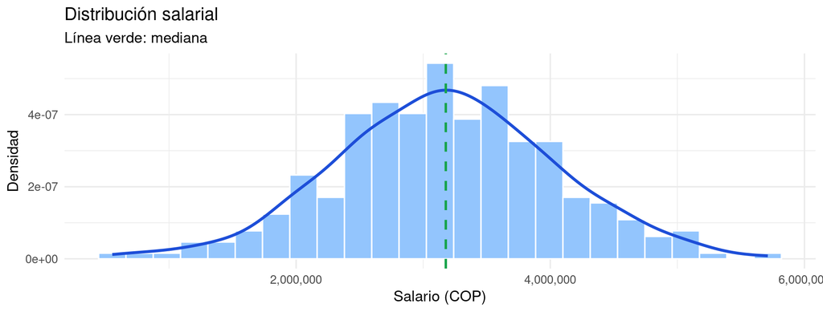

```r
ggplot(empleados, aes(x = salario)) +
  geom_histogram(aes(y = after_stat(density)),
                 bins = 25, fill = "#93c5fd", color = "white") +
  geom_density(color = "#1d4ed8", linewidth = 1.2) +
  geom_vline(aes(xintercept = median(salario)),
             color = "#16a34a", linetype = "dashed", linewidth = 1) +
  scale_x_continuous(labels = scales::comma) +
  labs(title = "Distribución salarial", subtitle = "Línea verde: mediana",
       x = "Salario (COP)", y = "Densidad") +
  theme_minimal(base_size = 14)
```

## El número de bins importa

#### Pocos bins (5)

Ocultan la forma real. La distribución parece más suave o uniforme de lo que es.

#### Bins adecuados (25-30)

Revelan la estructura sin introducir ruido excesivo.

#### Muchos bins (200)

Introducen ruido. Cada bin tiene pocos datos y la forma se vuelve ilegible.

Regla práctica: prueba con la raíz cuadrada de n como punto de partida, luego ajusta visualmente. `bins = sqrt(nrow(datos))`

## Curva de densidad

La densidad (KDE: Kernel Density Estimation) suaviza el histograma mediante una función continua. El área bajo la curva siempre suma 1.

#### Ventaja sobre histograma

No depende de la elección de bins. Muestra la forma continua de la distribución.

#### Parámetro de suavizado

`bw` (bandwidth) controla el nivel de suavizado. Un valor mayor da una curva más suave pero menos detallada.

#### Uso ideal

Comparar distribuciones de grupos superponiéndolas en el mismo gráfico.

## Densidad en R: comparación entre grupos

- Código
- Gráfico

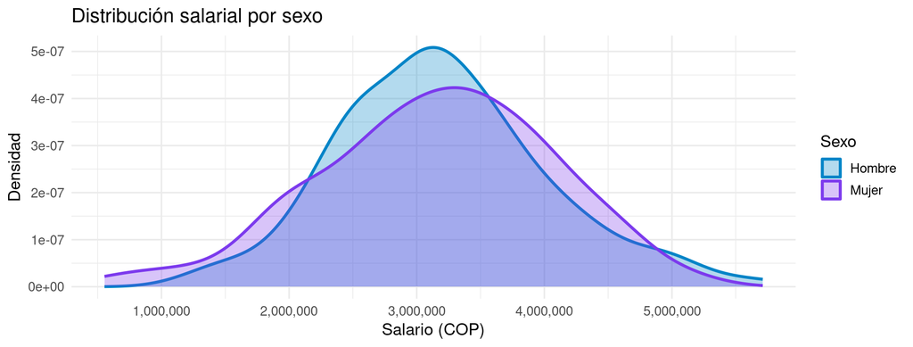

```r
ggplot(empleados, aes(x = salario, fill = sexo, color = sexo)) +
  geom_density(alpha = 0.3, linewidth = 1.1) +
  scale_fill_manual(values = c("Mujer" = "#7c3aed", "Hombre" = "#0284c7")) +
  scale_color_manual(values = c("Mujer" = "#7c3aed", "Hombre" = "#0284c7")) +
  scale_x_continuous(labels = scales::comma) +
  labs(title = "Distribución salarial por sexo",
       x = "Salario (COP)", y = "Densidad", fill = "Sexo", color = "Sexo") +
  theme_minimal(base_size = 14)
```

`alpha = 0.3` hace las áreas semitransparentes para ver el traslape entre distribuciones.

## El boxplot: anatomía

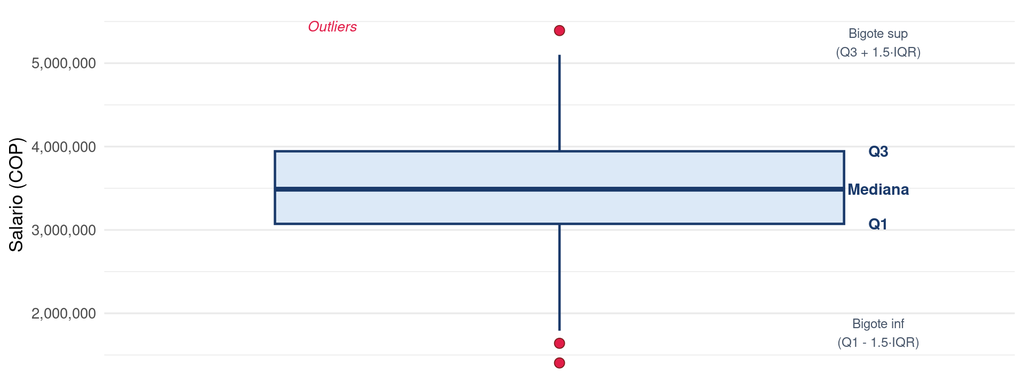

- **Caja:** del Q1 al Q3 (IQR = Q3 - Q1)
- **Línea interna:** mediana (Q2)
- **Bigotes:** hasta 1.5 × IQR
- **Puntos:** valores fuera de 1.5 × IQR

## Boxplot y violin en R

- Código
- Gráfico

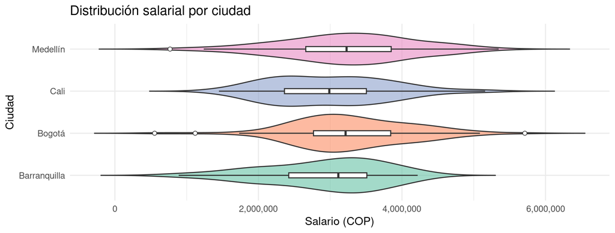

```r
ggplot(empleados, aes(x = ciudad, y = salario, fill = ciudad)) +
  geom_violin(trim = FALSE, alpha = 0.6, show.legend = FALSE) +
  geom_boxplot(width = 0.12, fill = "white",
               outlier.shape = 21, outlier.size = 2, show.legend = FALSE) +
  scale_fill_brewer(palette = "Set2") +
  scale_y_continuous(labels = scales::comma) +
  labs(title = "Distribución salarial por ciudad",
       x = "Ciudad", y = "Salario (COP)") +
  coord_flip() +
  theme_minimal(base_size = 13)
```

`coord_flip()` rota el gráfico: ideal cuando los nombres de las categorías son largos.

## Distribuciones comunes

#### Normal (simétrica)

Media = Mediana = Moda. Bigotes casi iguales. IQR centrado.

Referencia teórica

#### Sesgada a la derecha

Cola larga hacia la derecha. Media > Mediana. Frecuente en ingresos, precios, tiempos.

Muy común en datos reales

#### Bimodal

Dos picos. Indica mezcla de poblaciones o mecanismos distintos. Señal de segmentación.

Investiga el origen

## Asimetría, medidas y decisiones

| Indicador | Qué mide | Función en R |
| --- | --- | --- |
| Media | Centro ponderado (sensible a extremos) | `mean(x)` |
| Mediana | Centro robusto (valor del 50%) | `median(x)` |
| Desviación estándar | Dispersión promedio | `sd(x)` |
| IQR | Dispersión robusta (Q3 - Q1) | `IQR(x)` |
| Percentiles | Posición relativa dentro del rango | `quantile(x, probs)` |
| Asimetría (skew) | Dirección e intensidad del sesgo | `e1071::skewness(x)` |

## Resumen estadístico en R

```r
# summary() da los 5 números + media
summary(empleados$salario)

# Resumen más completo con dplyr
empleados |>
  summarise(
    n         = n(),
    media     = mean(salario),
    mediana   = median(salario),
    desv_std  = sd(salario),
    iqr       = IQR(salario),
    p25       = quantile(salario, 0.25),
    p75       = quantile(salario, 0.75),
    minimo    = min(salario),
    maximo    = max(salario)
  ) |>
  mutate(across(everything(), \(x) round(x, 0)))
```

## Distribuciones y decisiones en minería de datos

1. **Sesgo fuerte:** evaluar transformación logarítmica antes de modelar.
2. **Outliers extremos:** decidir entre eliminar, winsorizar o usar modelos robustos.
3. **Bimodalidad:** sospechar la presencia de subpoblaciones distintas.
4. **Cola pesada:** verificar si los modelos asumen normalidad.
5. **Distribución uniforme:** puede indicar variable sin información predictiva.

Parte 7

## Ejercicios de práctica

Aplica lo aprendido en R, sube tu análisis a GitHub y entrega mediante Pull Request.

## Dataset para los ejercicios

```r
library(tidyverse)
set.seed(2025)

n <- 400
estudiantes <- tibble(
  id         = 1:n,
  programa   = sample(c("Estadística","Sistemas","Economía","Matemáticas"),
                      n, replace = TRUE, prob = c(.3,.3,.25,.15)),
  semestre   = sample(1:10, n, replace = TRUE),
  sexo       = sample(c("Mujer","Hombre"), n, replace = TRUE),
  nota_final = round(rnorm(n, mean = 3.5, sd = 0.7), 1) |> pmin(5) |> pmax(0),
  horas_sem  = round(rnorm(n, mean = 18, sd = 5)),
  beca       = sample(c("Sí","No"), n, replace = TRUE, prob = c(.3,.7))
)
```

Guarda este dataset como `estudiantes` en tu script. Todos los ejercicios lo usan.

## Ejercicio 1: ¿es normal la distribución de notas?

Aplica una prueba formal de normalidad a `nota_final` para cada programa por separado.

```r
library(tidyverse)

# Prueba de Shapiro-Wilk por programa
estudiantes |>
  group_by(programa) |>
  summarise(
    W       = shapiro.test(nota_final)$statistic,
    p_valor = shapiro.test(nota_final)$p.value
  )
```

1. ¿En qué programas se rechaza normalidad con alpha = 0.05?
2. Construye el QQ-plot para el programa con el p-valor más bajo. ¿Qué patrón ves en las colas?
3. Si la distribución no es normal, ¿qué implicaciones tiene para pruebas de hipótesis posteriores?

## Ejercicio 2: estadísticos robustos y sesgo

Construye una tabla que compare estimadores clásicos y robustos de centralidad y dispersión.

```r
estudiantes |>
  group_by(programa) |>
  summarise(
    media       = mean(nota_final),
    mediana     = median(nota_final),
    media_recortada = mean(nota_final, trim = 0.1),  # trim 10%
    mad         = mad(nota_final),                   # desv. absoluta mediana
    cv          = sd(nota_final) / mean(nota_final), # coef. variación
    asimetria   = (mean(nota_final) - median(nota_final)) / sd(nota_final)
  )
```

1. ¿Qué programa muestra mayor discrepancia entre media y media recortada? ¿Qué indica?
2. Interpreta el coeficiente de asimetría de Pearson: ¿en qué dirección sesga cada distribución?
3. ¿Cuándo preferirías reportar la MAD en lugar de la desviación estándar?

## Ejercicio 3: valores atípicos

Compara dos criterios de detección de outliers y discute sus diferencias.

```r
detectar_outliers <- function(x) {
  q1  <- quantile(x, 0.25); q3 <- quantile(x, 0.75)
  iqr <- q3 - q1
  z   <- (x - mean(x)) / sd(x)
  tibble(
    valor      = x,
    outlier_iqr = x < (q1 - 1.5 * iqr) | x > (q3 + 1.5 * iqr),
    outlier_z   = abs(z) > 3
  )
}

estudiantes |>
  group_by(programa) |>
  reframe(detectar_outliers(nota_final)) |>
  summarise(n_iqr = sum(outlier_iqr), n_z = sum(outlier_z))
```

1. ¿Coinciden los dos criterios? ¿Cuándo podría el criterio Z fallar con muestras pequeñas?
2. Visualiza los outliers detectados por IQR sobre un boxplot con `geom_point()` en color rojo.
3. ¿Eliminarías esos puntos del análisis? Justifica estadísticamente.

## Ejercicio 4: correlación y su significancia

Analiza la relación entre horas de estudio y nota final usando dos coeficientes.

```r
# Pearson (asume linealidad y normalidad) vs Spearman (no paramétrico)
estudiantes |>
  group_by(programa) |>
  summarise(
    r_pearson  = cor(horas_sem, nota_final, method = "pearson"),
    r_spearman = cor(horas_sem, nota_final, method = "spearman"),
    p_pearson  = cor.test(horas_sem, nota_final, method = "pearson")$p.value,
    p_spearman = cor.test(horas_sem, nota_final, method = "spearman")$p.value
  )
```

1. ¿En qué programas hay correlación significativa? ¿Pearson y Spearman coinciden?
2. Si Spearman > Pearson en algún programa, ¿qué sugiere sobre la forma de la relación?
3. Grafica el dispersograma con `geom_smooth(method = “lm”)` separado por programa con `facet_wrap()`.

## Ejercicio 5: comparación de grupos con tamaño del efecto

Prueba si las notas difieren entre programas y cuantifica qué tan grande es esa diferencia.

```r
# Kruskal-Wallis (no paramétrico, no asume normalidad)
kruskal.test(nota_final ~ programa, data = estudiantes)

# Tamaño del efecto: eta-cuadrado de Kruskal-Wallis
# eta^2 = (H - k + 1) / (n - k)  donde H es el estadístico y k el número de grupos
H <- kruskal.test(nota_final ~ programa, data = estudiantes)$statistic
k <- n_distinct(estudiantes$programa)
n <- nrow(estudiantes)
eta2 <- (H - k + 1) / (n - k)
eta2
```

1. ¿Se rechaza la hipótesis nula? Interpreta el p-valor en contexto.
2. Interpreta eta-cuadrado: ¿el efecto es pequeño (< 0.06), mediano (0.06-0.14) o grande (> 0.14)?
3. Si hay diferencias, aplica Dunn con corrección de Bonferroni para identificar qué pares difieren.

## Ejercicio 6: análisis completo en RMarkdown

Integra los cinco ejercicios anteriores en un documento reproducible con esta estructura:

1. **Descripción del dataset:** n, variables, tipos, valores faltantes.
2. **Normalidad:** Shapiro-Wilk por grupo + QQ-plots. Conclusión: ¿paramétrico o no paramétrico?
3. **Estadísticos robustos:** tabla con media, mediana, MAD y coeficiente de asimetría.
4. **Outliers:** tabla comparativa IQR vs Z con visualización.
5. **Correlación:** Pearson vs Spearman por programa con dispersogramas.
6. **Conclusión estadística:** Kruskal-Wallis + tamaño del efecto + prueba post-hoc.

## Flujo de entrega vía Pull Request

1. Fork  
   Copiar el repo del curso

→

2. Clone  
   Bajar el fork al PC

→

3. Branch  
   `git switch -c taller_09`

→

4. Commit & Push  
   Subir trabajo al fork

→

5. Pull Request  
   Solicitar revisión

## Cómo hacer el PR: comandos

```
# En la terminal, dentro del repo clonado:

git switch -c taller_09

# Agrega tus archivos en:
# entregas/grupo_X/TuNombre/taller_09/

git add entregas/grupo_X/TuNombre/taller_09/
git commit -m "Taller 09: visualización y distribuciones - TuNombre"
git push origin taller_09
```

Después del `git push`, ve a GitHub, abre tu fork y haz clic en **“Compare & Pull Request”**. El PR debe ir al repositorio del profesor, rama `main`.

## Checklist de entrega

| Requisito | Verificar |
| --- | --- |
| Carpeta en la ruta correcta | `entregas/grupo_X/TuNombre/taller_09/` |
| Archivo principal | `taller_09.Rmd` o `taller_09.qmd` |
| El código corre sin errores | Ejecuta `knit` o `quarto render` antes de subir |
| Rutas relativas | No hay rutas absolutas como `C:/Users/…` |
| Mensaje de commit claro | `“Taller 09: … - NombreApellido”` |
| PR al repositorio correcto | Base: `afflorezr/dm_2016325`, rama `main` |

## Resumen de herramientas vistas

ggplot2

Gramática visual. Gráficos estáticos de alta calidad para informes.

plotly

Interactividad. `ggplotly()` convierte cualquier ggplot.

highcharter

Gráficos elegantes. API expresivo con `hchart()`.

gt / kable

Tablas académicas en R. Pandas y Styler en Python.

## Resumen de la clase

1. El tipo de dato y la pregunta determinan el gráfico: no al revés.
2. `ggplot2` es la base para gráficos estáticos con control total.
3. `plotly` y `highcharter` agregan interactividad con poca fricción.
4. Tablas y gráficos se complementan: uno da exactitud, el otro da patrón.
5. Las distribuciones de frecuencia revelan forma, centro, dispersión y outliers antes del modelado.

## Próxima clase

**Clase 10: Medidas estadísticas y visualización de datos.**  
Profundizaremos en medidas de tendencia central, dispersión y posición. Aprenderemos a elegir la medida correcta según la distribución del dato.

**Para la próxima clase:** intenta ejecutar al menos uno de los ejercicios de hoy en R. No es necesario que esté completo, solo que el código corra sin errores.